# Practical Machine Learning

Divakar

Thursday, February 12, 2015

## Summary:

To apply machine learning algorithms to predict human activity recognition . Data from http://groupware.les.inf.puc-rio.br/har is used for this purpose Training data will be divided into two parts 80% for training and 20% for validating . Based on outcome of initial models , other models will be built. Goal is to achieve 90% accuracy .

### Load data

```r
library(caret)
library(randomForest)
pml <- read.csv("pml-training.csv" , na.strings=c("","NA"))
dim(pml)
```

```
## [1] 19622   160
```

### Divide data into two sets

```r
trainIndex <- createDataPartition(pml$classe, p = 0.80,list=FALSE)
training <- pml[trainIndex,]
validating <- pml[-trainIndex,]
```

### Explore and clean training data

Verify how many fields are NA . Calculate ratio of non-NA to NA

```r
ratio_non_na_to_na <- sum(!is.na(training)) / sum(is.na(training))
ratio_non_na_to_na
```

```
## [1] 0.6336108
```

There are more NAs than non NA . Keep columns if it contains less than 30% NA . Drop other columns

```r
rowCount <- nrow(training)
training <- training[,colSums(is.na(training)) < 0.3 * rowCount]
dim(pml)
```

```
## [1] 19622   160
```

Take a look at and check if some columns can be dropped without causing any issues. By observation of data , X ,user_name ,cvtd_timestamp,new_window columns can be dropped .(output not produced to reduce clutter)

```r
training <- training[, - c(1,2,5,6)]
dim(training)
```

```
## [1] 15699    56
```

check for near zero variance

```r
nzv <- nearZeroVar(training[,-c(56)])
nzv
```

```
## integer(0)
```

There are no nearZero variance columns.  
Identify highly correlated columns and drop them

```r
DatCorr <- cor(training[,-c(56)])
highCorr <- findCorrelation(DatCorr, 0.80)
training <- training [,-highCorr]
dim(training)
```

```
## [1] 15699    44
```

With a large set of 43 predictors , random forest gives better result .

### Random Forest model with cross validation of 4 fold. Estimate accuracy

```r
trControl <- trainControl(method = "cv", number = 4)
rf <- train(classe ~ ., method = "rf", trControl = trControl, data=training)
rf
```

```
## Random Forest
##
## 15699 samples
##    43 predictor
##     5 classes: 'A', 'B', 'C', 'D', 'E'
##
## No pre-processing
## Resampling: Cross-Validated (4 fold)
##
## Summary of sample sizes: 11774, 11774, 11775, 11774
##
## Resampling results across tuning parameters:
##
##   mtry  Accuracy   Kappa      Accuracy SD  Kappa SD
##    2    0.9965604  0.9956491  0.001819339  0.0023013720
##   22    0.9992993  0.9991138  0.000525218  0.0006643011
##   43    0.9960509  0.9950051  0.002085301  0.0026375160
##
## Accuracy was used to select the optimal model using  the largest value.
## The final value used for the model was mtry = 22.
```

```r
rf$finalModel
```

```
##
## Call:
##  randomForest(x = x, y = y, mtry = param$mtry)
##                Type of random forest: classification
##                      Number of trees: 500
## No. of variables tried at each split: 22
##
##         OOB estimate of  error rate: 0.05%
## Confusion matrix:
##      A    B    C    D    E  class.error
## A 4462    1    0    0    1 0.0004480287
## B    0 3038    0    0    0 0.0000000000
## C    0    2 2735    1    0 0.0010956903
## D    0    0    2 2570    1 0.0011659541
## E    0    0    0    0 2886 0.0000000000
```

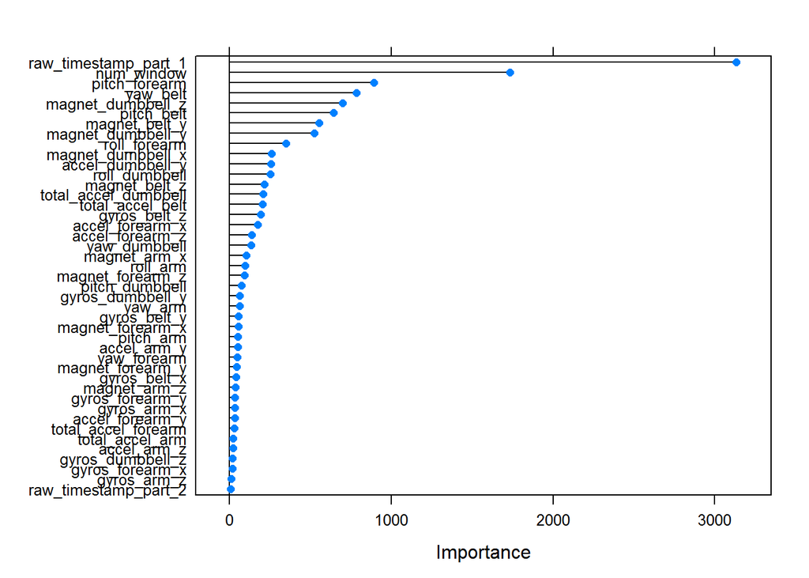

```r
plot(varImp(rf, scale = FALSE))
```

Based on above data ,Out of sample Error estimated to be 0.1%

### Test model with validating data , create confusionMatrix and verify out of sample accuracy

```r
predictions <- predict(rf, validating)

confusionMatrix(predictions, validating$classe)
```

```
## Confusion Matrix and Statistics
##
##           Reference
## Prediction    A    B    C    D    E
##          A 1116    1    0    0    0
##          B    0  758    4    0    0
##          C    0    0  680    0    0
##          D    0    0    0  643    0
##          E    0    0    0    0  721
##
## Overall Statistics
##
##                Accuracy : 0.9987
##                  95% CI : (0.997, 0.9996)
##     No Information Rate : 0.2845
##     P-Value [Acc > NIR] : < 2.2e-16
##
##                   Kappa : 0.9984
##  Mcnemar's Test P-Value : NA
##
## Statistics by Class:
##
##                      Class: A Class: B Class: C Class: D Class: E
## Sensitivity            1.0000   0.9987   0.9942   1.0000   1.0000
## Specificity            0.9996   0.9987   1.0000   1.0000   1.0000
## Pos Pred Value         0.9991   0.9948   1.0000   1.0000   1.0000
## Neg Pred Value         1.0000   0.9997   0.9988   1.0000   1.0000
## Prevalence             0.2845   0.1935   0.1744   0.1639   0.1838
## Detection Rate         0.2845   0.1932   0.1733   0.1639   0.1838
## Detection Prevalence   0.2847   0.1942   0.1733   0.1639   0.1838
## Balanced Accuracy      0.9998   0.9987   0.9971   1.0000   1.0000
```

Accuracy of more than .99 indicate , algorithm worked correctly and out of sample error is within predicted range